# Analysis of MEA data

Federico Menéndez Conde

2022-06-15

For each video, six regions of interest (roi) are considered. Three for each subject (patient and therapist): head, torso and legs. The exploratory analysis is done in two parts:

1. In the first part, we look for 5 minutes segments with high lagged correlation for some roi.
2. In the second part, we look for 30 second periods with high movement of both subjects. Cross correlations are performed and visualized for those high movement periods.

### First part

Basic information of the 26 videos is registered in table *bitacora*. Here we show the top entries of this table.

| file | sampling_rate | id_paciente | date | corte_inicial | corte_final | paciente | terapeuta |
| --- | --- | --- | --- | --- | --- | --- | --- |
| Vid0 | 30 | 1 | 24/04/2012 | 0 | 0 | Enrique:TNP | Iván |
| Vid5 | 30 | 1 | 01/05/2012 | 0 | 0 | Enrique:TNP | Iván |
| Vid6 | 30 | 1 | 03/05/2012 | 0 | 0 | Enrique:TNP | Iván |
| Vid7Inv | 30 | 1 | 14/03/2013 | 0 | 0 | Enrique:TNP | Iván |
| Vid8Inv | 30 | 1 | 19/03/2013 | 0 | 0 | Enrique:TNP | Iván |

The list *completa* contains the data for each of the videos listed in *bitacora*. As an example, *completa[[‘Vid5’]]* is a data set with 86084 observations. At a sampling rate of 30 frames per second, this corresponds to 47.82 minutes for the video *Vid5*. Its first entries are shown below.

Top entries for Vid5 raw data.

| tiempo | cabeza_paciente | torso_paciente | piernas_paciente | cabeza_terapeuta | torso_terapeuta | piernas_terapeuta |
| --- | --- | --- | --- | --- | --- | --- |
| 1 | 14447 | 16605 | 5333 | 33111 | 47080 | 75432 |
| 2 | 2850 | 13 | 759 | 5036 | 5272 | 10237 |
| 3 | 1229 | 6 | 276 | 3761 | 5864 | 9211 |
| 4 | 70 | 7 | 0 | 4622 | 7795 | 19966 |
| 5 | 49 | 52 | 0 | 11452 | 19099 | 37113 |
| 6 | 81 | 61 | 0 | 17414 | 20704 | 38285 |
| 7 | 32 | 27 | 0 | 13582 | 14550 | 28746 |
| 8 | 213 | 15 | 0 | 8707 | 10282 | 30627 |
| 9 | 416 | 2 | 0 | 6804 | 19605 | 36326 |
| 10 | 665 | 15 | 0 | 9098 | 20439 | 34309 |

```r
lista_seleccionados<-data.frame(matrix(ncol = 10,nrow = 0))

for (video in names(completa)){
      temp <- crear_lista(partition_data(completa[[video]]),
                          nombre = video,umbral_max = 0.7,umbral_mean = 0.5)
      names(lista_seleccionados)<-names(temp)
      lista_seleccionados<-rbind(lista_seleccionados,temp)
}

lista_seleccionados<-cbind(id=1:dim(lista_seleccionados)[1],lista_seleccionados)
lista_seleccionados<-filter(lista_seleccionados,abs(lag_spearman_max)>0.025)

write.csv(lista_seleccionados,"lista_seleccionados.csv",row.names = FALSE)
```

Five minute segments with high lagged correlation. Lags are shown in seconds, with positive values corresponding to lags where the therapist leads.

[output not shown]

We include two functions functions *comparativa_visual* and *corr_cruzadas* for visualizing the data of the segments with high correlation. The fundamental input for both functions is the number in the *id* column of *lista_seleccionados*.

```
## function (id, min_ini = 0, min_fin = 100, que_lista = lista_seleccionados)
## {
##     temp <- corta_lista(id, ls = que_lista)[[1]]
##     temp2 <- corta_lista(id, ls = que_lista)
##     g <- ggplot() + geom_line(data = filter(temp, tiempo > min_ini,
##         tiempo < min_fin), aes(tiempo, suave_paciente), color = "blue",
##         size = 0.5) + geom_line(data = filter(temp, tiempo >
##         min_ini, tiempo < min_fin), aes(tiempo, suave_terapeuta),
##         color = "brown", size = 0.5) + ggtitle(temp2[["video"]]) +
##         xlab("minuto en el video") + ylab("Azul: paciente. Rojo: terapeuta. (Promedios por segundo)")
##     show(g)
##     return(g)
## }
```

```
## function (id, que_lista = lista_seleccionados)
## {
##     temp <- corta_lista(id, ls = que_lista)[[1]]
##     cecefe <- ccf(temp$suave_paciente, temp$suave_terapeuta,
##         plot = FALSE, lag.max = 57)
##     aux <- data.frame(segundos = cecefe$lag[, 1, 1]/19, correlacion = cecefe$acf[,
##         1, 1])
##     temp2 <- corta_lista(id, ls = que_lista)
##     g <- ggplot(aux, aes(segundos, correlacion)) + geom_col(color = "orange",
##         fill = "purple") + ggtitle(paste(temp2[["video"]], temp2[["minutos"]],
##         sep = "                 ")) + xlab("lidera paciente       <--   segundos de desface   -->       lidera terapeuta") +
##         ylab("correlaciones cruzadas")
##     show(g)
##     return(g)
## }
```

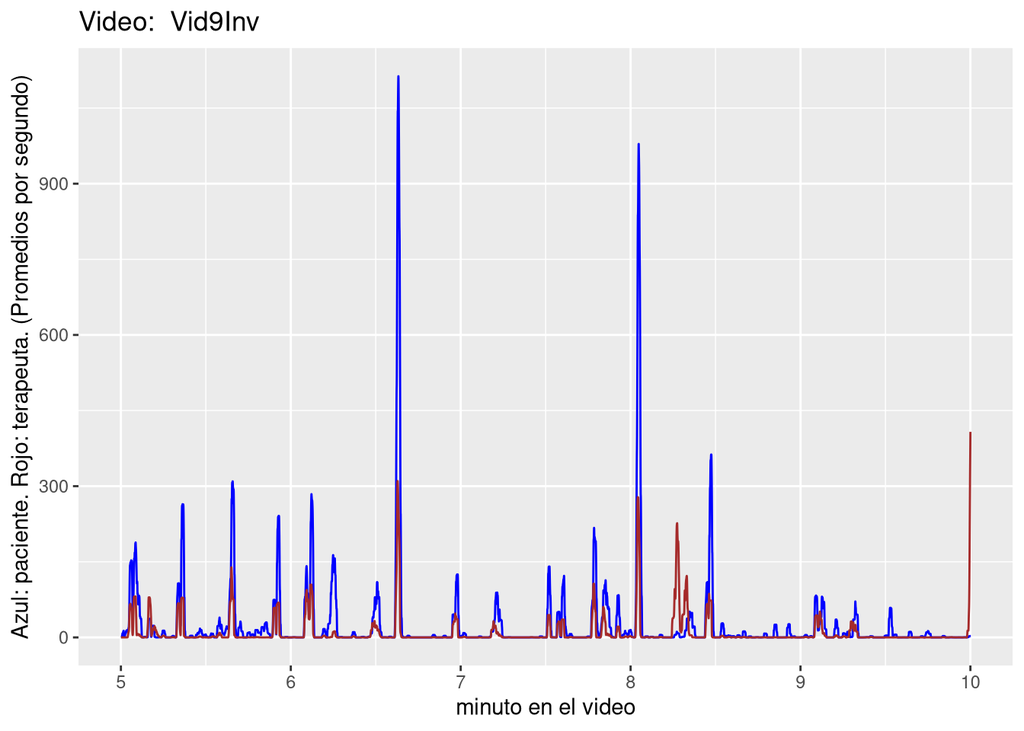

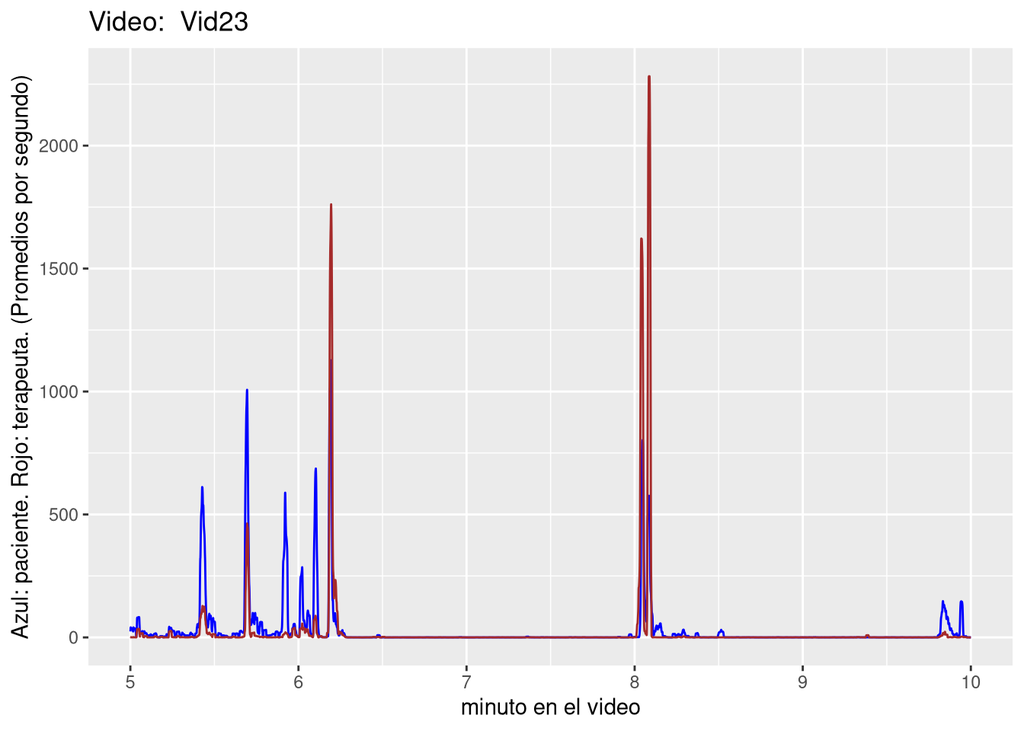

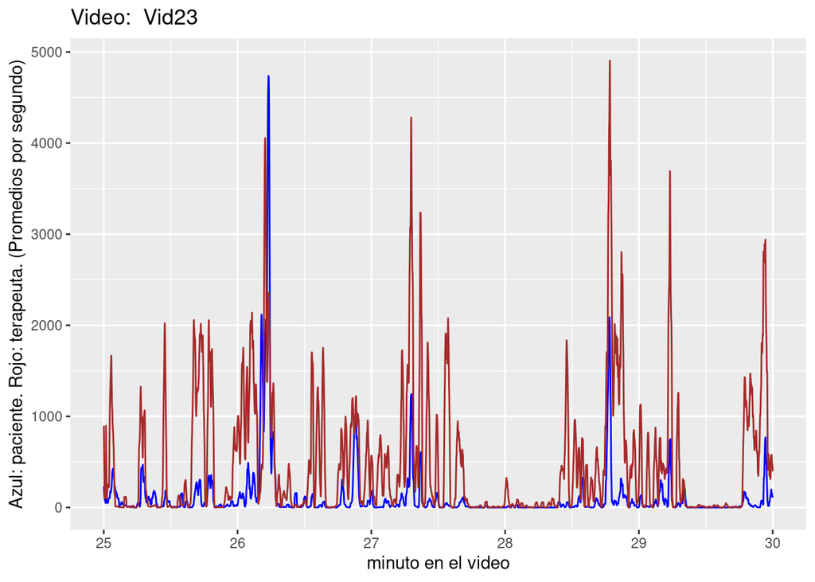

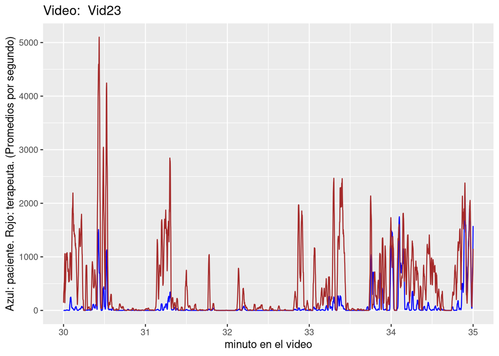

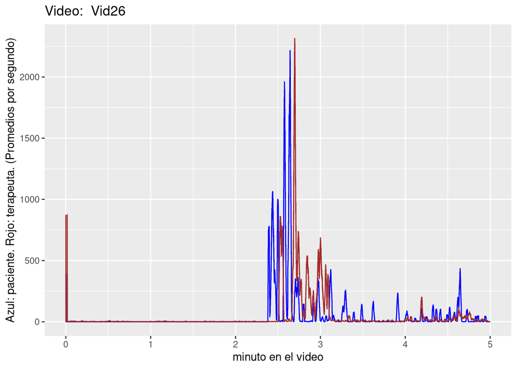

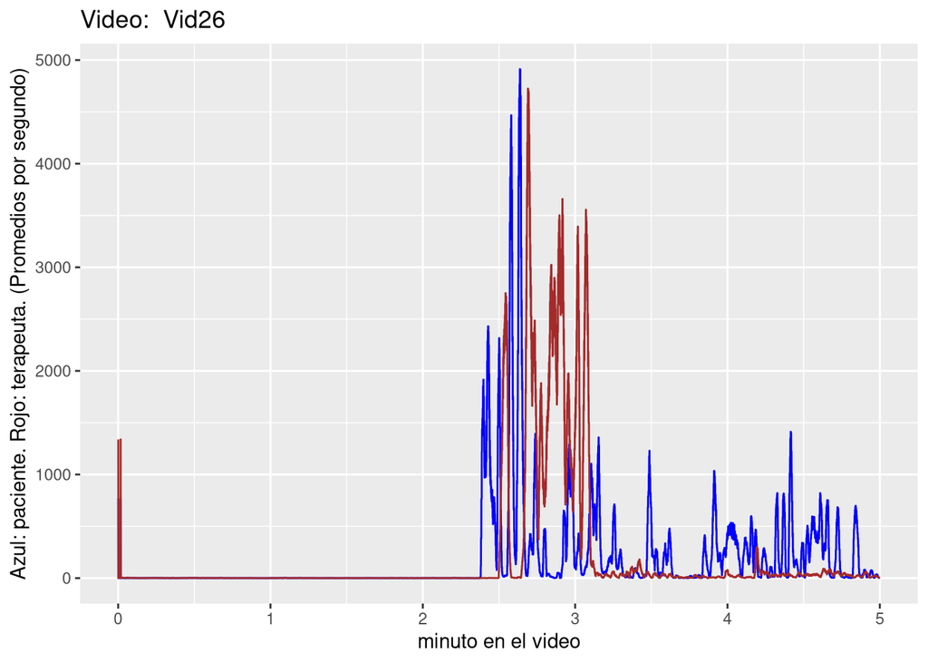

The function *corr_cruzadas* shows the cross correlation between movements of both subjects at lags of up to 3 seconds (in both directions). The plots are generated below.

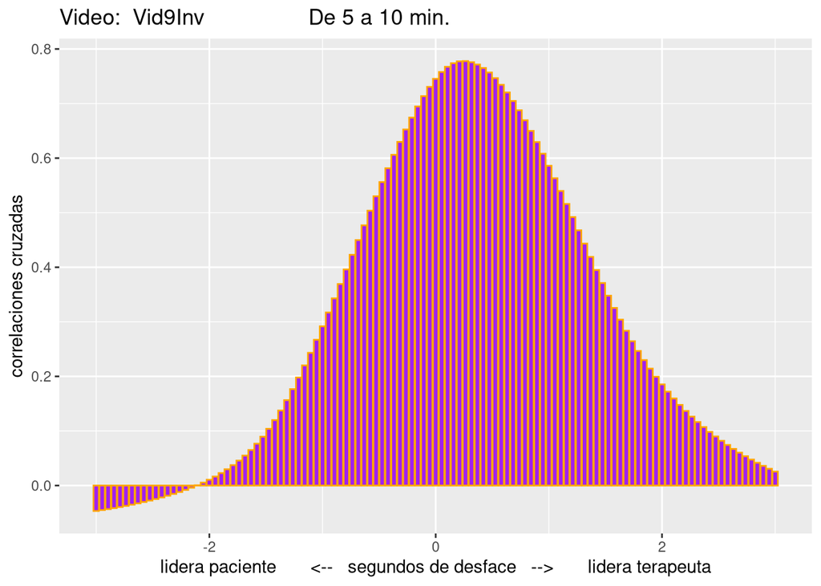

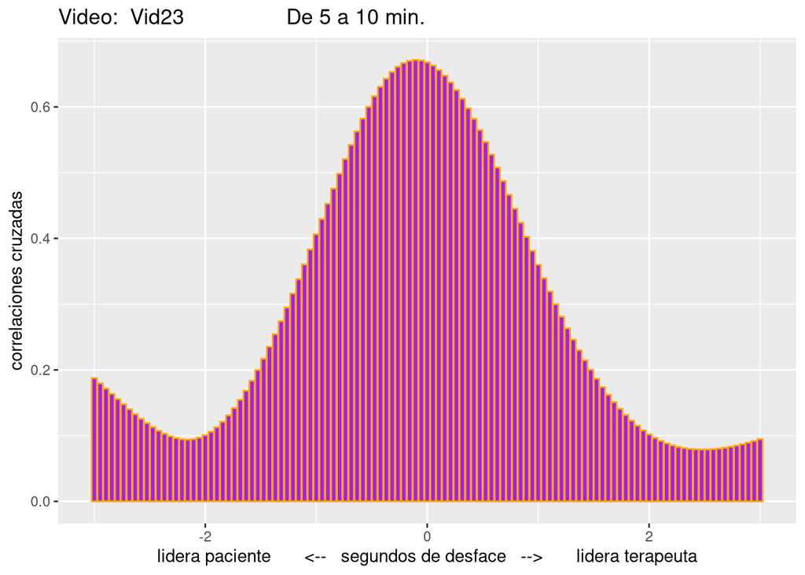

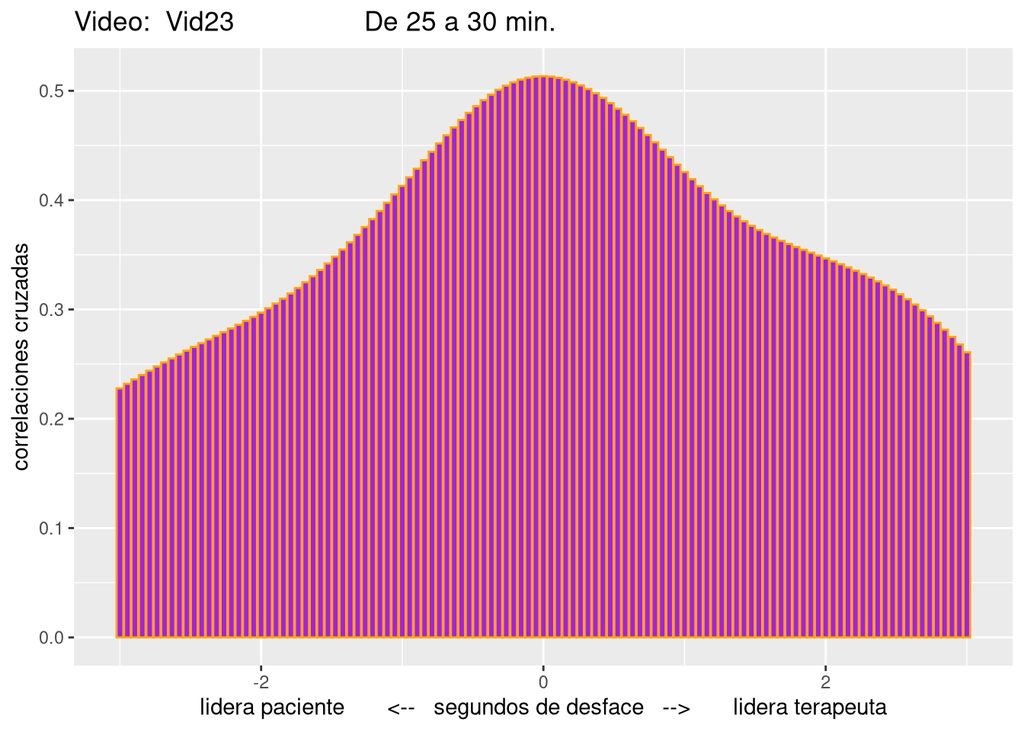

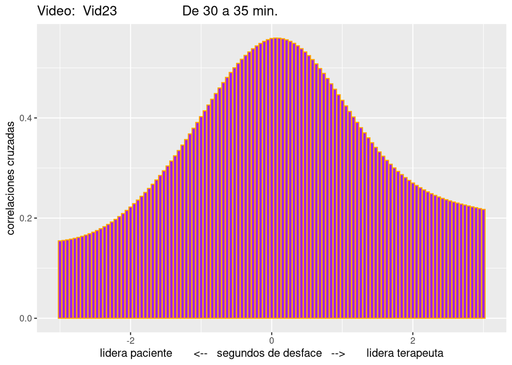

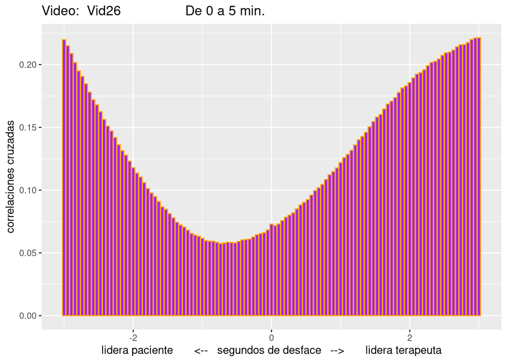

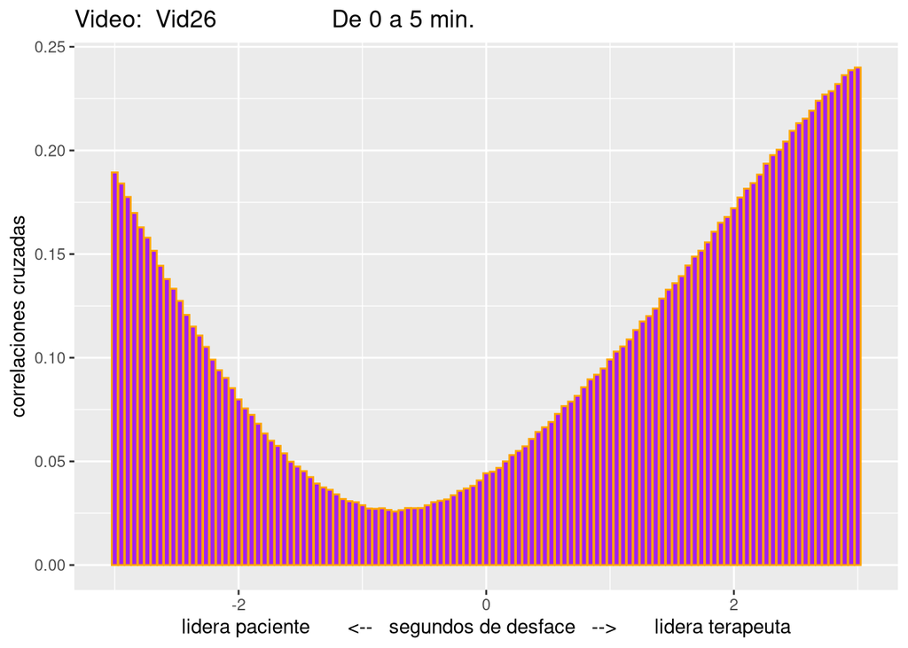

With the function *comparativa_visual* we can zoom in to look into shorter periods of time. As an example, we generate the plot of the first segment (id=1) from minute 7.1 to minute 8.6:

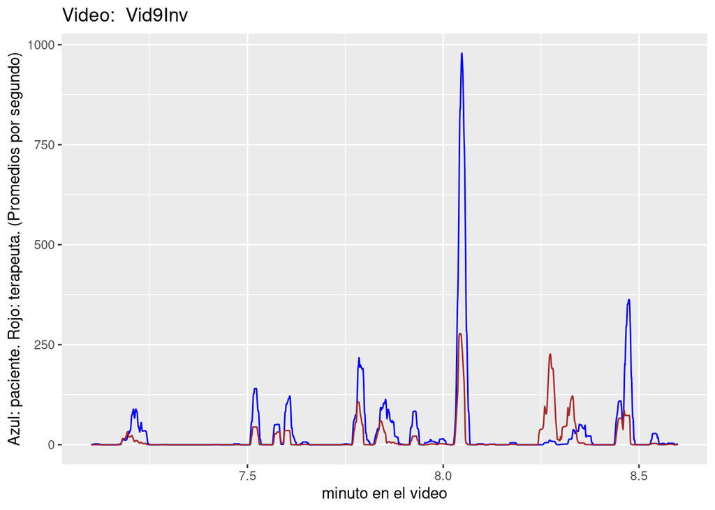

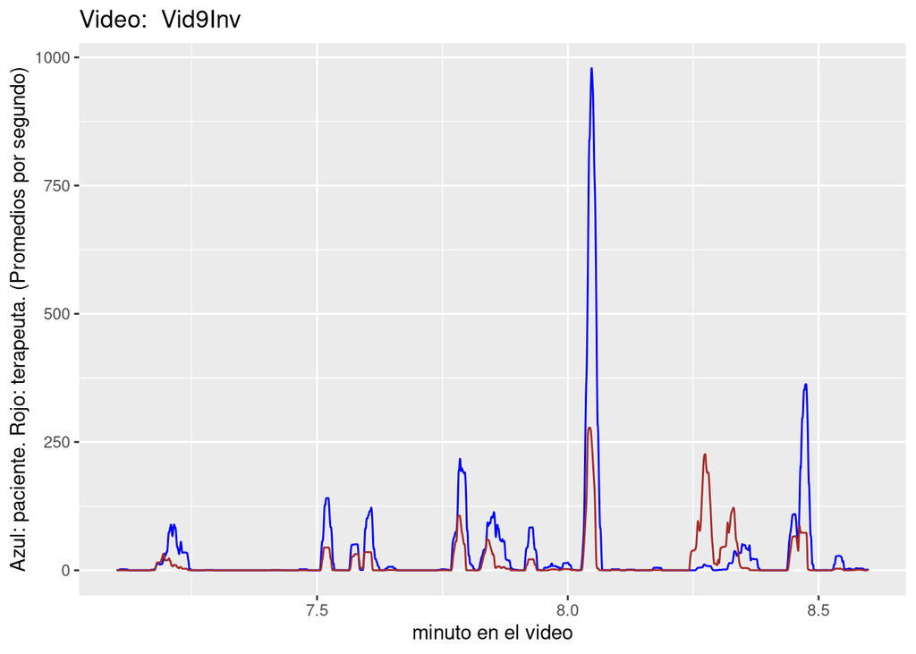

```r
comparativa_visual(id=1,min_ini = 7.1,min_fin = 8.6)
```